# Practical Machine Learning - Course Project

Anita Windisch

September 2018

## Project and Data Set Overview

The goal of this assignment is to predict the manner in which peolpe did their exercise. This is the **classe** variable in the training set. Using devices such like Fitbit it is now possible to collect a large amount of data about personal activity relatively inexpensively. One thing that people regularly do is quantify how much of a particular activity they do, but they rarely quantify how well they do it. They were asked to perform barbell lifts correctly and incorrectly in 5 different ways.

Furthermore citing the authors’ webpage we have: “Six young health participants were asked to perform one set of 10 repetitions of the Unilateral Dumbbell Biceps Curl in five different fashions: exactly according to the specification (Class A), throwing the elbows to the front (Class B), lifting the dumbbell only halfway (Class C), lowering the dumbbell only halfway (Class D) and throwing the hips to the front (Class E).”

## Working With The Data Set and Modeling

In the first part of this project we try to predict the manner in which the participants did the exercise. After that, in the second part we use the prediction model to predict 20 different test cases.

To get started I am loading the training data set:

```r
dataTrain<-read.csv("/home/anita/mycourses/DataScienceSpecialization/PracticalMachineLearning/pml-training.csv",
header = TRUE, sep=",")
dim(dataTrain)
```

```
## [1] 19622   160
```

```r
str(dataTrain[,1:30])
```

```
## 'data.frame':    19622 obs. of  30 variables:
##  $ X                   : int  1 2 3 4 5 6 7 8 9 10 ...
##  $ user_name           : Factor w/ 6 levels "adelmo","carlitos",..: 2 2 2 2 2 2 2 2 2 2 ...
##  $ raw_timestamp_part_1: int  1323084231 1323084231 1323084231 1323084232 1323084232 1323084232 1323084232 1323084232 1323084232 1323084232 ...
##  $ raw_timestamp_part_2: int  788290 808298 820366 120339 196328 304277 368296 440390 484323 484434 ...
##  $ cvtd_timestamp      : Factor w/ 20 levels "02/12/2011 13:32",..: 9 9 9 9 9 9 9 9 9 9 ...
##  $ new_window          : Factor w/ 2 levels "no","yes": 1 1 1 1 1 1 1 1 1 1 ...
##  $ num_window          : int  11 11 11 12 12 12 12 12 12 12 ...
##  $ roll_belt           : num  1.41 1.41 1.42 1.48 1.48 1.45 1.42 1.42 1.43 1.45 ...
##  $ pitch_belt          : num  8.07 8.07 8.07 8.05 8.07 8.06 8.09 8.13 8.16 8.17 ...
##  $ yaw_belt            : num  -94.4 -94.4 -94.4 -94.4 -94.4 -94.4 -94.4 -94.4 -94.4 -94.4 ...
##  $ total_accel_belt    : int  3 3 3 3 3 3 3 3 3 3 ...
##  $ kurtosis_roll_belt  : Factor w/ 397 levels "","-0.016850",..: 1 1 1 1 1 1 1 1 1 1 ...
##  $ kurtosis_picth_belt : Factor w/ 317 levels "","-0.021887",..: 1 1 1 1 1 1 1 1 1 1 ...
##  $ kurtosis_yaw_belt   : Factor w/ 2 levels "","#DIV/0!": 1 1 1 1 1 1 1 1 1 1 ...
```

[output cut: 16 more lines]

Looking at the variables in the data set (partially displayed) we can see that many of those have plenty of **NAs** and **blank values**. That`s why the next step is to clean the data.

```r
# Looking for the index of the columns which have at least 70% of NA and blank values.
index<-which(colSums(is.na(dataTrain)|dataTrain=="")>0.7)
# Taking this columns out of the data set.
dataCleanTrain<-dataTrain[,-index]
# The first 7 columns are irrelevant for the model: user name and several time stamps.
dataCleanTrain<-dataCleanTrain[,-c(1:7)]
# New dimension of the data set with fewer variables
dim(dataCleanTrain)
```

```
## [1] 19622    53
```

```r
str(dataCleanTrain[,1:30])
```

```
## 'data.frame':    19622 obs. of  30 variables:
##  $ roll_belt           : num  1.41 1.41 1.42 1.48 1.48 1.45 1.42 1.42 1.43 1.45 ...
##  $ pitch_belt          : num  8.07 8.07 8.07 8.05 8.07 8.06 8.09 8.13 8.16 8.17 ...
##  $ yaw_belt            : num  -94.4 -94.4 -94.4 -94.4 -94.4 -94.4 -94.4 -94.4 -94.4 -94.4 ...
##  $ total_accel_belt    : int  3 3 3 3 3 3 3 3 3 3 ...
##  $ gyros_belt_x        : num  0 0.02 0 0.02 0.02 0.02 0.02 0.02 0.02 0.03 ...
##  $ gyros_belt_y        : num  0 0 0 0 0.02 0 0 0 0 0 ...
##  $ gyros_belt_z        : num  -0.02 -0.02 -0.02 -0.03 -0.02 -0.02 -0.02 -0.02 -0.02 0 ...
##  $ accel_belt_x        : int  -21 -22 -20 -22 -21 -21 -22 -22 -20 -21 ...
##  $ accel_belt_y        : int  4 4 5 3 2 4 3 4 2 4 ...
##  $ accel_belt_z        : int  22 22 23 21 24 21 21 21 24 22 ...
##  $ magnet_belt_x       : int  -3 -7 -2 -6 -6 0 -4 -2 1 -3 ...
##  $ magnet_belt_y       : int  599 608 600 604 600 603 599 603 602 609 ...
##  $ magnet_belt_z       : int  -313 -311 -305 -310 -302 -312 -311 -313 -312 -308 ...
##  $ roll_arm            : num  -128 -128 -128 -128 -128 -128 -128 -128 -128 -128 ...
```

[output cut: 16 more lines]

After cleaning the data set we are going to the next step which regards partitioning of the data set.

```r
library(caret) # Loading needed library
set.seed(2018) # Set random seed
# Make a partition of the data: 60% Train and 40% Test
Training<-createDataPartition(dataCleanTrain$classe,p=0.6,list=FALSE)
Train<-dataCleanTrain[Training,]
Test<-dataCleanTrain[-Training,]
# Dimensions
dim(Train)
```

```
## [1] 11776    53
```

```r
dim(Test)
```

```
## [1] 7846   53
```

## Model Testing

With the partitions ready to work with, we start by testing 2 different prediction models: **Predicting with trees** and **Random forest**. To improve the effeciency of the models and also to reduce overfitting, we will use the **cross validation** method. Thats why we define the **trainControl()** function as **trainControl(method=“cv”, number=5)** where **method** is set as **cross validation** with **number of folds** equals **5**.

```r
trconFun<-trainControl(method="cv", number=5) # Explanation above!
```

### 1. Predicting with Trees

```r
library(rattle)
```

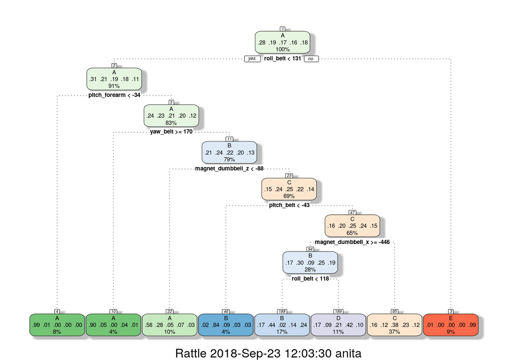

```r
# Training our model
model_trees<-train(classe~., data=Train, method="rpart", trControl=trconFun)
# Plot the final model
fancyRpartPlot(model_trees$finalModel)
```

```r
# Predicting
prediction_withTrees<-predict(model_trees, newdata=Test)
# Calculating confusion matrix
confMatr1<-confusionMatrix(Test$classe,prediction_withTrees)
confMatr1$overall[1] # Extracting the accuracy percentage for the model
```

```
##  Accuracy
## 0.5457558
```

The accuracy for this model is about **55%** which is not very good. That means that the outcome (**classe**) is not good predicted by the other predictors.

### 2. Predicting with Random Forest

```r
# Training the model
model_randforest<-train(classe~., data=Train, ntree=10, method="rf",trControl=trconFun, verbose=FALSE)
# Displying the final model
model_randforest$finalModel
```

```
##
## Call:
##  randomForest(x = x, y = y, ntree = 10, mtry = param$mtry, verbose = FALSE)
##                Type of random forest: classification
##                      Number of trees: 10
## No. of variables tried at each split: 27
##
##         OOB estimate of  error rate: 3.82%
## Confusion matrix:
##      A    B    C    D    E class.error
## A 3259   37    6   13    2  0.01748568
## B   52 2135   37   13   17  0.05279503
## C   13   57 1922   31    6  0.05273534
## D   10   17   58 1816   14  0.05169713
## E    4   22   16   21 2083  0.02935694
```

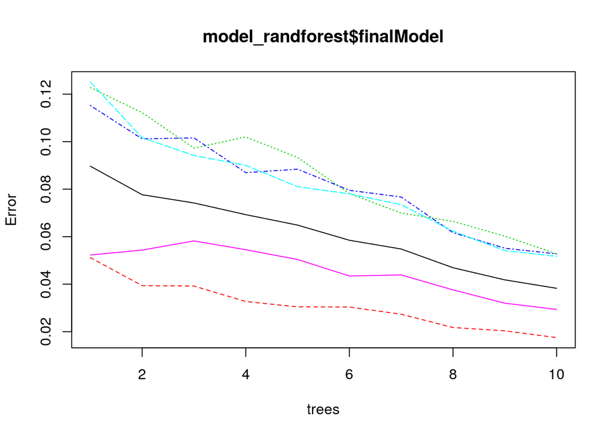

```r
# Plotting the final model
plot(model_randforest$finalModel)
```

```r
# Predicting with Random Forest
prediction_withRandForest<-predict(model_randforest, newdata=Test)
# Calculating confusion matrix
confMatr2<-confusionMatrix(Test$classe,prediction_withRandForest)
confMatr2$overall[1] # Extracting the accuracy percentage for the model
```

```
## Accuracy
## 0.986235
```

With the **Random Forest** model the accuracy of the prediction process is way better. I trained my random forest model only with **ntree=10** and my final model has a **99%** accuracy with only **27 predictors** (**mtry** is the number of predictors). The error rate is also low, only **4%**, which is good.

Comparing the 2 tested models the optimal model for our case is the **Random Forest Model**.

## Using predicting model to predict 20 different test cases

In this second and final part of the project we take our random forest model from above and predict 20 different cases. First, we are taking a look at this data set.

```r
dataTest<-read.csv("/home/anita/mycourses/DataScienceSpecialization/PracticalMachineLearning/pml-testing.csv")
dim(dataTest)
```

```
## [1]  20 160
```

```r
str(dataTest[,1:20])
```

```
## 'data.frame':    20 obs. of  20 variables:
##  $ X                   : int  1 2 3 4 5 6 7 8 9 10 ...
##  $ user_name           : Factor w/ 6 levels "adelmo","carlitos",..: 6 5 5 1 4 5 5 5 2 3 ...
##  $ raw_timestamp_part_1: int  1323095002 1322673067 1322673075 1322832789 1322489635 1322673149 1322673128 1322673076 1323084240 1322837822 ...
##  $ raw_timestamp_part_2: int  868349 778725 342967 560311 814776 510661 766645 54671 916313 384285 ...
##  $ cvtd_timestamp      : Factor w/ 11 levels "02/12/2011 13:33",..: 5 10 10 1 6 11 11 10 3 2 ...
##  $ new_window          : Factor w/ 1 level "no": 1 1 1 1 1 1 1 1 1 1 ...
##  $ num_window          : int  74 431 439 194 235 504 485 440 323 664 ...
##  $ roll_belt           : num  123 1.02 0.87 125 1.35 -5.92 1.2 0.43 0.93 114 ...
##  $ pitch_belt          : num  27 4.87 1.82 -41.6 3.33 1.59 4.44 4.15 6.72 22.4 ...
##  $ yaw_belt            : num  -4.75 -88.9 -88.5 162 -88.6 -87.7 -87.3 -88.5 -93.7 -13.1 ...
##  $ total_accel_belt    : int  20 4 5 17 3 4 4 4 4 18 ...
##  $ kurtosis_roll_belt  : logi  NA NA NA NA NA NA ...
##  $ kurtosis_picth_belt : logi  NA NA NA NA NA NA ...
##  $ kurtosis_yaw_belt   : logi  NA NA NA NA NA NA ...
##  $ skewness_roll_belt  : logi  NA NA NA NA NA NA ...
##  $ skewness_roll_belt.1: logi  NA NA NA NA NA NA ...
##  $ skewness_yaw_belt   : logi  NA NA NA NA NA NA ...
##  $ max_roll_belt       : logi  NA NA NA NA NA NA ...
##  $ max_picth_belt      : logi  NA NA NA NA NA NA ...
##  $ max_yaw_belt        : logi  NA NA NA NA NA NA ...
```

```r
# Looking for the index of the columns which have at least 70% of NA and blank values.
index<-which(colSums(is.na(dataTest)|dataTest=="")>0.7)
# Taking this columns out of the data set.
dataCleanTest<-dataTest[,-index]
# The first 6 columns are irrelevant for the model: user name and several time stamps.
dataCleanTest<-dataCleanTest[,-c(1:6)]
# New dimension of the data set with fewer variables
dim(dataCleanTest)
```

```
## [1] 20 54
```

```r
str(dataCleanTest[,1:20])
```

```
## 'data.frame':    20 obs. of  20 variables:
##  $ num_window      : int  74 431 439 194 235 504 485 440 323 664 ...
##  $ roll_belt       : num  123 1.02 0.87 125 1.35 -5.92 1.2 0.43 0.93 114 ...
##  $ pitch_belt      : num  27 4.87 1.82 -41.6 3.33 1.59 4.44 4.15 6.72 22.4 ...
##  $ yaw_belt        : num  -4.75 -88.9 -88.5 162 -88.6 -87.7 -87.3 -88.5 -93.7 -13.1 ...
##  $ total_accel_belt: int  20 4 5 17 3 4 4 4 4 18 ...
##  $ gyros_belt_x    : num  -0.5 -0.06 0.05 0.11 0.03 0.1 -0.06 -0.18 0.1 0.14 ...
##  $ gyros_belt_y    : num  -0.02 -0.02 0.02 0.11 0.02 0.05 0 -0.02 0 0.11 ...
##  $ gyros_belt_z    : num  -0.46 -0.07 0.03 -0.16 0 -0.13 0 -0.03 -0.02 -0.16 ...
##  $ accel_belt_x    : int  -38 -13 1 46 -8 -11 -14 -10 -15 -25 ...
##  $ accel_belt_y    : int  69 11 -1 45 4 -16 2 -2 1 63 ...
##  $ accel_belt_z    : int  -179 39 49 -156 27 38 35 42 32 -158 ...
##  $ magnet_belt_x   : int  -13 43 29 169 33 31 50 39 -6 10 ...
##  $ magnet_belt_y   : int  581 636 631 608 566 638 622 635 600 601 ...
##  $ magnet_belt_z   : int  -382 -309 -312 -304 -418 -291 -315 -305 -302 -330 ...
##  $ roll_arm        : num  40.7 0 0 -109 76.1 0 0 0 -137 -82.4 ...
##  $ pitch_arm       : num  -27.8 0 0 55 2.76 0 0 0 11.2 -63.8 ...
##  $ yaw_arm         : num  178 0 0 -142 102 0 0 0 -167 -75.3 ...
##  $ total_accel_arm : int  10 38 44 25 29 14 15 22 34 32 ...
##  $ gyros_arm_x     : num  -1.65 -1.17 2.1 0.22 -1.96 0.02 2.36 -3.71 0.03 0.26 ...
##  $ gyros_arm_y     : num  0.48 0.85 -1.36 -0.51 0.79 0.05 -1.01 1.85 -0.02 -0.5 ...
```

Now I am making the prediction for the 20 different cases:

```r
model<-predict(model_randforest, newdata=dataCleanTest)
print(model)
```

```
##  [1] B A B A A E D B A A B C B A E E A B B B
## Levels: A B C D E
```